# Project 3: Data Visualisation

## Multivariate Exploration

### BorrowerAPR across ProsperRating and Loan Terms

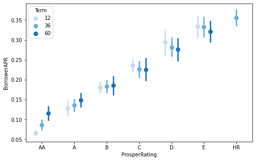

```python
#plotting pointplot
fig = plt.figure(figsize = [8,5])
ax = sns.pointplot(data = data, x = 'ProsperRating', y = 'BorrowerAPR', hue = 'Term',
           palette = 'Blues', linestyles = '',dodge = 0.4, ci='sd')
```

From the plot above, it can be seen as annual cost increases, longer term time was required from AA to B, it became constant at C while at D and E rating respectively, they required a lesser annual cost over a long period of time.

### BorrowerAPR across LoanStatus and LoanOriginalAmount

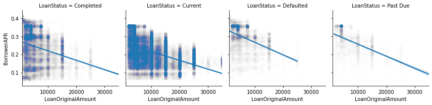

```python
#Facetplot of BorrowerAPR VS LoanStatus and LoanOriginalAmount
g = sns.FacetGrid(data = data, col = 'LoanStatus', col_wrap = 4)
g.map(sns.regplot,'LoanOriginalAmount', 'BorrowerAPR', x_jitter = 0.05, scatter_kws = {'alpha': 0.005});
```

From the plots above, the following can be deduced:

```
* The higher the borrowerAPR, the lesser the original amount collected for all the above loan status.

* Thw lower the borrowerAPR, the higher the original amount collected for those with current loan status

* More customers currently paying up their loans than any other loan status categories
```

### LoanOriginalAmount across ProsperRating and EmploymentStatus

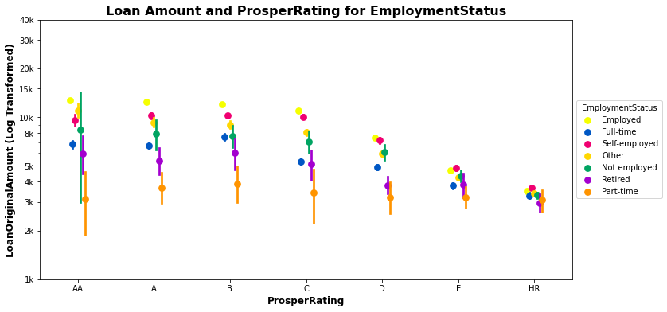

```python
#plotsize
plt.figure(figsize = [12,6])
#pointplot of ProsperRating, LoanOriginalAmount and LoanStatus
ax = sns.pointplot(data = data, x = 'ProsperRating', y = 'LoanOriginalAmount', hue = 'EmploymentStatus', dodge = 0.2, linestyles="",
                  palette="prism")
#title
plt.title('Loan Amount and ProsperRating for EmploymentStatus',weight = "bold", fontsize = 16);
#legend
plt.legend(title='EmploymentStatus',loc = "center left", bbox_to_anchor = (1, 0.5))
#xlabel
plt.xlabel('ProsperRating',weight = "bold", fontsize = 12)
#ylabel
plt.ylabel('LoanOriginalAmount (Log Transformed)',weight = "bold", fontsize = 12)
#yscale
plt.yscale('log')
#yticks
plt.yticks([1e3, 2e3,3e3,4e3, 5e3, 8e3,1e4, 15e3,2e4,3e4,4e4], ['1k', '2k','3k','4k' ,'5k','8k', '10k','15k','20k','30k','40k']);
plt.xticks(rotation= 0)
plt.show();
```

From the plot above, It can be seen as the amount of loan collected increases, there's a decrease from A to HR. Also, it can be seen that loans were given out mostly to customers that were employed.

### BorrowerAPR across Terms and IncomeRange

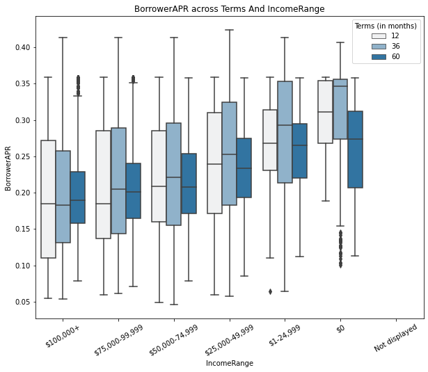

```python
fig = plt.figure(figsize = [10, 8])
ax = sns.boxplot(x='IncomeRange', y='BorrowerAPR', hue='Term',
                 data=data, color=color)
plt.title('BorrowerAPR across Terms And IncomeRange')
plt.legend(title = 'Terms (in months)')
plt.xticks(rotation=30);
```

It's intriguing to see this. The APR rises as the income range narrows for each particular period across each bracket. Usually, the APR goes down as the period lengthens, however in this case, it goes up when the income range drops from 100,000 to zero.

### EmploymentStatus across mean_BorrowerAPR and ProsperRating

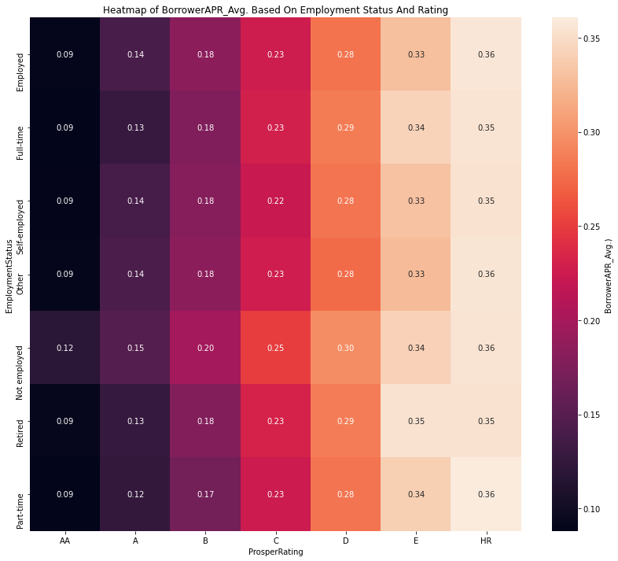

```python
means = data.groupby(['ProsperRating', 'EmploymentStatus']).mean()['BorrowerAPR']
means = means.reset_index(name = 'BorrowerAPR_Avg.')
means = means.pivot(index = 'EmploymentStatus', columns = 'ProsperRating',
                       values = 'BorrowerAPR_Avg.')
sns.heatmap(means, annot = True, fmt = '.2f', cbar_kws = {'label': 'BorrowerAPR_Avg.)'})
plt.title('Heatmap of BorrowerAPR_Avg. Based On Employment Status And Rating');
```

### Talk about some of the relationships you observed in this part of the investigation. Were there features that strengthened each other in terms of looking at your feature(s) of interest?

- The distribution of the ProperRatings between the BorrowerAPR and the Loan Amount is good.
- While longer term loans are associated with greater loan amounts and a well-distributed borrowerAPR, shorter term loans have better borrowerAPR and lower loan amounts.
- High incomes can borrow more money and have favourable borrowerAPRs.